# IODS course project

# Introduction to Open Data Science - Course Project

# About the project

```r
# This is a so-called "R chunk" where you can write R code.

date()
```

```
## [1] "Thu Dec  7 19:21:47 2023"
```

From this course I expect to learn step by step methods for analysing data systematically by using various statistical tools.I heard about this course from the coordinators of doctoral programme of Helsinki University.

I read the book “R for Health Data Science” until chapter 4. This book is really helpful to learn R tools. In this book all the important topics explained precisely and briefly to use RStudio. To me the most interesting topic was using tidyverse package. I never knew that how tidyverse package make the life easy for data frame management by using various functions such as mutate(), filter(), arrange() etc.I am excited to learn the use of R Markdown, it seems extremely helpfull to produce nice reports in R.

Link for github repository: https://github.com/khaleda58/IODS-project

https://khaleda58.github.io/IODS-project/

# Linear Regression Analysis

## Loading required packages

```r
library(tidyverse)
```

```r
library(ggplot2)
```

## Step 1

## Reading data

```r
students2014 <- read.csv("Data/learning2014.csv")

dim(students2014)
```

```
## [1] 166   7
```

```r
str(students2014)
```

```
## 'data.frame':    166 obs. of  7 variables:
##  $ gender  : chr  "F" "M" "F" "M" ...
##  $ age     : int  53 55 49 53 49 38 50 37 37 42 ...
##  $ attitude: num  3.7 3.1 2.5 3.5 3.7 3.8 3.5 2.9 3.8 2.1 ...
##  $ deep    : num  3.58 2.92 3.5 3.5 3.67 ...
##  $ stra    : num  3.38 2.75 3.62 3.12 3.62 ...
##  $ surf    : num  2.58 3.17 2.25 2.25 2.83 ...
##  $ points  : int  25 12 24 10 22 21 21 31 24 26 ...
```

In this data set, 166 observations of 7 variables are available. This data set tells about the points obtained from a group of people through answering some questionnaires. Group of people were categorized based on gender, age and attitude, additionally questionnaires were categorized into: (1) deep questions which variable name is “deep”, (2) surface questions, which variable name is “surf” and (3) strategic question, which variable name is “stra”.

## Step 2

### Graphical overview

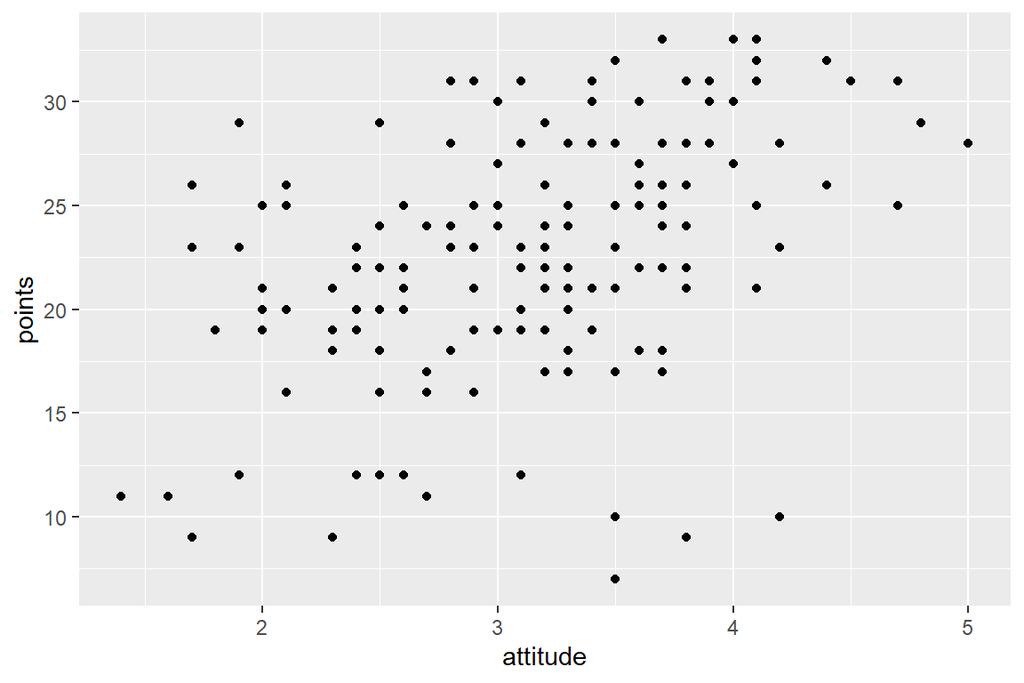

```r
# Access the gglot2 library
library(ggplot2)

# initialize plot with data and aesthetic mapping
p1 <- ggplot(students2014, aes(x = attitude, y = points))

# define the visualization type (points)
p2 <- p1 + geom_point()

# draw the plot
p2
```

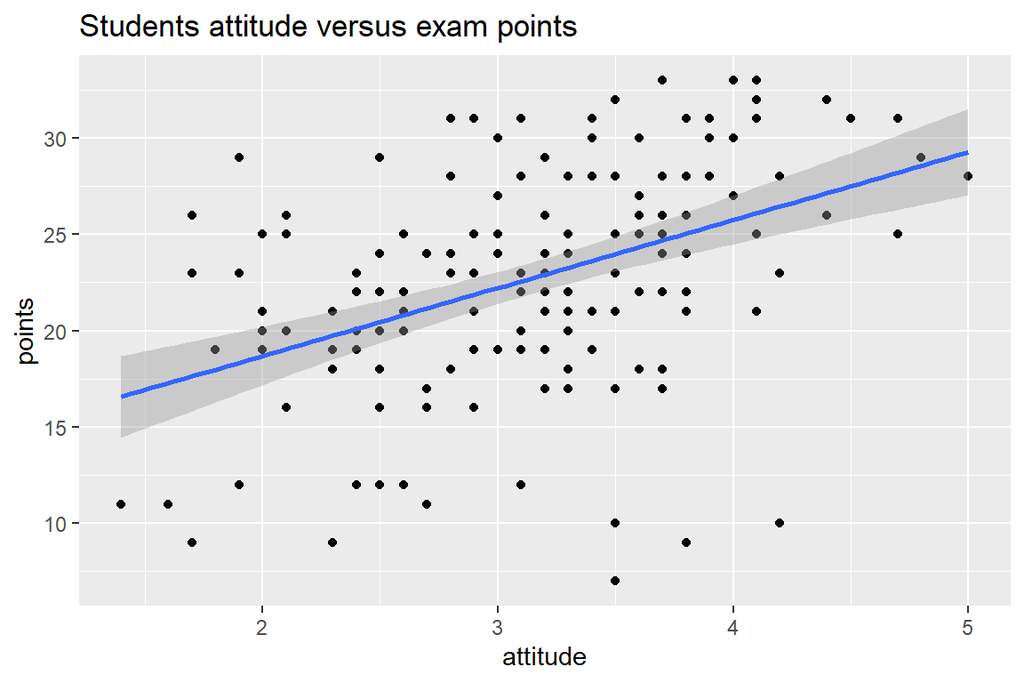

```r
# add a regression line
p3 <- p2 + geom_smooth(method = "lm")

# add a main title
p4 <- p3 + ggtitle('Students attitude versus exam points')

p4
```

This above scatter plots indicates the linear relationship between points and attitude.